# PSA Data Table

Paul Medley

21/09/2018

# Introduction

This is a preliminary analysis of the available length frequency data for Bangladesh fisheries. These assessments will need to be updated and corrected. Species have been removed from this assessment for a variety of reasons. These reasons include grouped data not identified to species level, insufficient data collected and numerical problems with software when attempting to fit. In the latter case, further work will be required to understand why and what can be done. For example, the analysis depends on the rstan package which is not necessarily compatible with the latest R versions, so some work-around might be required to complete these minority of species.

# Fishbase

Data are collected from fishbase using application programming interface (API) calls. The species list is a csv file.

Names are selected based on there presence in fishbase using the validate_names() function. Note that for animals not present in fishbase, the server is switched to sealifebase, and that database is searched separately.

Database tables are accessed using API functions. The fields are not well documented and presumably could change.

Fishbase should contain all fish and sharks, and sealifebase may contain the main shrimp and other non-scalefish species. The first task is to download the relevant information that exists for each species that we can find. Species (or species groups) that cannot be found are dropped from the analysis.

```r
# Only run if data not already downloaded. Fishbase API not always available.
#sp_to_assess

fbas_sp <- validate_names(SpeciesList, server = "fishbase")
fbas_sp <- tibble(Species=fbas_sp, sp2as=SpeciesList)

sbas_sp <- filter(fbas_sp, is.na(Species))
fbas_sp <- filter(fbas_sp, ! is.na(Species))
# validate names does not work for sealifebase, so this is dealt with later
# sbas_sp <- validate_names(sp_to_assess, server = "sealifebase") # bugged

fbsp <- species(pull(fbas_sp, Species), server="fishbase") |>
  select(Species, FBname, Length, LTypeMaxM, MaxLengthRef) |>
  arrange(Species)
fbgr <- popgrowth(pull(fbas_sp, Species), server="fishbase") |>
  select(Species, Sex, Data, Loo, K, M, Type, b, M, MethodGrowth,
         MethodM, DataSourceRef, PopGrowthRef, MRef)
fbma <- maturity(pull(fbas_sp, Species), server="fishbase") |>
  select(Species, Sex, Lm, SE_Lm, SD_Lm, Type1, LengthMatRef)
fblw <- poplw(pull(fbas_sp, Species), server="fishbase") |>
  select(Species, LengthMin, LengthMax, Sex, a, b, Method, PopLWRef)

sbsp <- species(pull(sbas_sp, sp2as), server="sealifebase") |>
  select(Species, FBname, Length, LTypeMaxM, MaxLengthRef)
sbgr <- popgrowth(pull(sbas_sp, sp2as), server="sealifebase") |>
  select(Species, Sex, Data, Loo, K, M, Type, b, M, MethodGrowth,
         MethodM, DataSourceRef, PopGrowthRef, MRef)
sbma <- maturity(pull(sbas_sp, sp2as), server="sealifebase") |>
  select(Species, Sex, Lm, SE_Lm, SD_Lm, Type1, LengthMatRef)
sblw <- poplw(pull(sbas_sp, sp2as), server="sealifebase") |>
  select(Species, LengthMin, LengthMax, Sex, a, b, Method, PopLWRef)

save(fbas_sp, sbas_sp, fbas_sp, fbsp, fbgr, fbma, fblw, sbsp, sbgr, sbma, sblw, file=here("data", "fishbase_downloads.rda"))
```

# Process Information

## Length Frequency Data

Length frequency data are combined into three gears for the species which have sufficient observations. All bin widths by default are 1cm.

```r
load(file=here("data", "BMFCBP_2012_2018.rda"))
load(file=here("data", "fishbase_downloads.rda"))
# Clean
# "Diaphus sp."
# "Euthynnus affinis"
# "Himantura walga"
# "Jaydia ellioti"
# "Johnius spp"
# "Lactarius lactarius"
# "Lagocephalus lagocephalus"
# "Lates calcarifer"
# "Megalaspis cordyla"
# "Metapenaeopsis stridulans"
# "Metapenaeopsis brevicornis"
# "Nematopalaemon tenuipes"
# "Octopus vulgaris"
# "Pampus chinenesis"
# "Parapenaeopsis hardwickii"


sv_lfd <- read_csv(here("data", "bansis_len_freq_data.csv"), show_col_types = FALSE) |>
  mutate(sciname = case_when(sciname == "Ariomma indicum" ~ "Ariomma indica",
                             sciname == "Stolephorus buccaneeri *" ~ "Stolephorus buccaneeri",
                             TRUE ~ sciname),
    species = case_when(
      sciname == "Callionymus carebares" ~ "CALCA15",
      sciname == "Charybdis hellerii" ~ "CRAPO03",
      sciname == "Cynoglossus quadrilineatus" ~ "CYGQA01",
      sciname == "Galene bispinosa" ~ "CRAGA01",
      sciname == "Iago omanensis" ~ "SHATR01",
      sciname == "Ilisha filigera" ~ "PRSIL05",
      sciname == "Ilisha megaloptera" ~ "PRSIL04",
      sciname == "Ilisha melastoma" ~ "PRSIL03",
      sciname == "Johnius borniensis" ~ "SCIJO10",
      sciname == "Johnius dussumieri" ~ "SCIJO02",
      sciname == "Lepidotrigla omanensis" ~ "TRGLE07",
      sciname == "Leptomelanosoma indicum" ~ "PLNLE01",
      sciname == "Minous inermis" ~ "SCRMI04",
      sciname == "Otolithoides pama" ~ "SCIOS02",
      sciname == "Parapenaeus longipes" ~ "SHRPE32",
      sciname == "Parapercis alboguttata" ~ "PINPA04",
      sciname == "Takifugu oblongus" ~ "TETTA01",
      sciname == "Zebrias zebra" ~ "SOLZE02",
      TRUE ~ species
    ),
    gear_type = "Survey"
  ) |>
  filter(!is.na(sciname)) |>
  group_by(species, sciname, gear_type, length_cm) |>
  summarise(fq = sum(frequency)) |>
  ungroup()


sv_spcode <- sv_lfd |>
  group_by(species, sciname) |>
  summarise() |>
  ungroup()

lf_df <- cbp_lf_dtl_df |>
  inner_join(cbp_lf_mst_df, by="lwf_tranid") |>
  filter(length_cm > 0,
         gear_type %in% c("Gill net", "Set Bagnet")) |>
  mutate(length_cm = as.integer(length_cm)) |>
  group_by(sciname, gear_type, length_cm) |>
  summarise(fq = n()) |>
  ungroup() |>
  rbind(select(sv_lfd, sciname, gear_type, length_cm, fq)) |>
  filter(sciname %in% sp_to_assess)

# The species names in the Bangladesh database are not necessarily the same as in Fishbase
fb_sp_to_assess <- pull(filter(fbas_sp, (sp2as %in% sp_to_assess)), Species)
fbgr <- fbgr |>
  filter(Species %in% fb_sp_to_assess)
```

## a, b

Otherwise, the aim is to build a table of reasonable priors for Linf, M, and estimates for Lm, a, b with notes.

For the available length-weight data, a simple log linear regression is applied to estimate the parameters $a$ and $b$:

$$W = a \ \ L^b$$

The $a$ parameter is not critical, but the $b$ parameter is used in estimating reasonable natural mortality.

```r
ar_lwd <- cbp_lf_dtl_df |>
  inner_join(cbp_lf_mst_df, by="lwf_tranid") |>
  select(sciname, length_cm, weight_g) |>
  filter(length_cm > 0, weight_g > 0) |>
  mutate(source = "Land_based")

sv_lwd <- read_csv(here("data", "bansis_len_wt_data.csv"), show_col_types = FALSE) |>
  inner_join(sv_spcode, by="species") |>
  filter(sciname %in% sp_to_assess) |>
  select(sciname, length_cm, weight_g=weight_gm) |>
  filter(length_cm > 0, weight_g > 0) |>
  mutate(source="survey")

lwd <- rbind(ar_lwd, sv_lwd) |>
  mutate(lweight_g=log(weight_g), llength_cm=log(length_cm))

sp_code <- lwd |>
  filter(!is.na(sciname)) |>
  group_by(sciname) |>
  summarise(N=n()) |>
  ungroup() |>
  filter(N>30) |>
  pull(sciname)

# regression line graph with species name
# store a, b and se

lw_res <- tibble()
gl <- list()
gi <- 0
for (spi in 1:length(sp_code)) {
  gi <- gi + 1
  df <- filter(lwd, sciname == sp_code[spi])
  OneSource <- (length(unique(pull(df, source))) == 1)

  if (OneSource) {
    mod <- summary(lm(formula = lweight_g~llength_cm, data=df))
    lw_res <- rbind(lw_res, tibble(name=sp_code[spi], a = exp(mod$coef[1,1]), b = mod$coef[2,1],
                           loga = mod$coef[1,1], loga_se = mod$coef[1,2],
                           b_se = mod$coef[2,2], loga_survey = NA))
  } else {
    df$source <- factor(df$source)
    mod <- summary(lm(formula = lweight_g~llength_cm + source, data=df))
    lw_res <- rbind(lw_res, tibble(name=sp_code[spi], a = exp(mod$coef[1,1]), b = mod$coef[2,1],
                           loga = mod$coef[1,1], loga_se = mod$coef[1,2],
                           b_se = mod$coef[2,2], loga_survey = mod$coef[1,1]+mod$coef[3,1]))
  }
  gl[[gi]] <- ggplot()
  if (OneSource) {
    gl[[gi]] <- ggplot(df, aes(x=llength_cm, y=lweight_g)) +
      geom_point(show.legend=FALSE) +
      scale_size_continuous(range = c(0.5,2)) +
      labs(x="log-length (cm)", y="log-weight (g)", title=sp_code[spi]) +
      geom_smooth(method="lm", formula = y ~ x)
  } else {
    gl[[gi]] <- ggplot(df, aes(x=llength_cm, y=lweight_g)) +
      geom_point(aes(colour=source), show.legend=FALSE) +
      scale_size_continuous(range = c(0.5,2)) +
      labs(x="log-length (cm)", y="log-weight (g)", title=sp_code[spi])
  }

  if (gi==4) {
    grid.arrange(gl[[1]], gl[[2]], gl[[3]], gl[[4]], ncol=2)
    gi <- 0
  }
}

if (gi != 0) {
  for (gii in (gi+1):4) gl[[gii]] <- ggplot()
  grid.arrange(gl[[1]], gl[[2]], gl[[3]], gl[[4]], ncol=2)
}

rm(gl, ar_lwd, sv_lwd, sp_code, mod, sv_spcode)
```

[output not shown]

Some species have been rejected due to a lack of consistent data. In some cases, species have not been specified, only species groups. In other cases, measurements seem not to have been taken consistently.

A recommendation is for the Scientific Survey to undertake morphometric studies, particularly of crustaceans, to allow consistent length measure measurements to be applies in models.

## Linf, L50, M/K

- Use $Linf$ and 2, 5 or 10cm sd dependent on scale of $Linf$, se.
- Use 90% max length and 10cm sd

The data are not grouped by sex. We assume where $Linf$ for sexes are given separately, either the differences are sbmall or the ratio is 50%, so the average with a greater uncertainty covers the $Linf$. Sex has not been recorded for any species in Bangladesh.

For measurement type, we assume a standard measurement if “NG” (not given) or “NA”. The only problem is when there is a mix of FL and TL measurements within a species. However, inspection of the estimates suggests that this is not a major source of error and other factors swamp any error introduced by this. Therefore, any variation this introduces forms part of the estimated $Linf$ prior sigma.

A recommendation is that the survey start to record sex specific lengths for species that show sexual dimorphism - primarily shrimp - and that in future analyses should allow mixture likelihoods for mixed unrecorded sexes.

The length-weight parameters are estimated preferably, or derived from Fishbase/Sealifebase using the estimates with the widest range of lengths. If the value for the $b$ parameter is outside the range 2.4 to 4.0, it is assumed to be invalid. If no other information is available, a default value of 3 for $b$ is used, and $a$ is set at an arbitrary value (note $a$ is not a critical parameter and is only used to scale the reported weights).

Data on $Lm$ was available from the artisanal land-based survey, but could not be used at this time because it could not be interpreted. It may be that the data are not valid and would have to be verified through the appropriate histology. If an appropriate $Lm$ estimate was available from Fishbase/Sealifebase it was used, otherwise a default $0.666\ Linf$ is used.

Two estimates of $M/K$ were estimated. These were either based on growth parameters from the linear regression model suggested by Griffiths and Harrod (2007) which was a simple update of Pauly(1980) regression. This required that growth parameters were available. The second estimate was taken from the life history invariant estimate from Prince et al. (2015) used by Hordyk et al. (2015). This required estimates of $b$, $Linf$ and $Lm$. Estimates were constrained to the range 1.0 to 3.0. Values outside this range were rejected.

```r
Bang_Temperature <- 28.5

Linf_SD <- function(Linf, Linf_se) {
  # Provides a value for the normal prior sigma
  Linf10 <- max(c(round(Linf*0.1), round(Linf_se)), na.rm=TRUE)
  if (Linf10 >= 8)
    Sigma <- 10
  else if (Linf10 < 2)
    Sigma <- 2
  else
    Sigma <- Linf10
  return(Sigma)
}

NatMort_Growth <- function(Linf, K, Tempr) {
  #' Natural mortality estimate
  #' based on Griffiths and Harrod (2007) species regression
  return(10^(0.102 - 0.066*log10(Linf) + 0.814*log10(K) + 0.19*log10(Tempr)))
}

NatMort_LHI <- function(Linf, Lm, b) {
  # Life history invariant estimate
  return(b*(Linf[1]-Lm)/Lm)
}

# Growth info
fbgr_sum <- fbgr |>
  group_by(Species) |>
  summarise(Linf = mean(Loo, na.rm=T),
            Linf_se = sd(Loo, na.rm=T),
            K = mean(K, na.rm=T),
            M = mean(M, na.rm=T),
            b = mean(b, na.rm=T),
            PopGrowthRef = first(PopGrowthRef),
            N=n()) |>
  ungroup() |>
  left_join(fbsp, by="Species") |>
  left_join(fbas_sp, by="Species")  # adds Bangladesh names as sp2as

# Select the length-weight parameters covering the greatest length range
fblw_sum <- fblw |>
  mutate(LengthRange = LengthMax-LengthMin) |>
  group_by(Species) |>
  slice(which.max(LengthRange)) |>
  ungroup() |>
  arrange(Species)


# Select the length-weight parameters covering the greatest length range
fbma_sum <- fbma |>
  filter(! is.na(Lm)) |>
  group_by(Species) |>
  summarise(Lm = mean(Lm, na.rm=T),
            LengthMatRef = first(na.omit(LengthMatRef)),
            N=n()) |>
  ungroup() |>
  arrange(Species)

Prior_df <- tibble()
for (spi in 1:nrow(fbgr_sum)) {
  fb_sp_name <- fbgr_sum$Species[spi]
  as_sp_name <- fbgr_sum$sp2as[spi]

  # Linf
  if (is.na(fbgr_sum$Linf[spi]) | (fb_sp_name== "Sillaginopsis panijus")) {
    # Use maximum length
    Linf <- fbgr_sum$Length[spi]*0.9  # Adjusted for bias
    Linf_se <- NA
    Linf_Notes = "Linf based on 90% Fishbase/Sealifebase reported maximum length."
    Linf_Ref <- fbgr_sum$MaxLengthRef[spi]
  } else {
    Linf <- fbgr_sum$Linf[spi]
    Linf_se <- fbgr_sum$Linf_se[spi]
    Linf_Notes = paste0("Linf mean of ",
                        format(fbgr_sum$N[spi]), " Fishbase/Sealifebase reported estimates.")
    Linf_Ref <- fbgr_sum$PopGrowthRef[spi]
  }

  # a, b
  lw_sp <- lw_res$name==as_sp_name
  fblw_sp <- fblw_sum$Species==fb_sp_name
  ab_estimated <- FALSE

  if (any(lw_sp)) {
    a <- lw_res$a[lw_sp]
    b <- lw_res$b[lw_sp]
    if (between(b, 2.4, 4.0)) {
      ab_estimated <- TRUE
      ab_Notes <- "Length-weight parameters estimated from Bangladesh data."
      ab_Ref <- 0
    }
  }
  if (! ab_estimated & any(fblw_sp)) {
    a <- fblw_sum$a[fblw_sp]
    b <- fblw_sum$b[fblw_sp]
    if (between(b, 2.4, 4.0)) {
      ab_estimated <- TRUE
      ab_Notes <- "Length-weight parameters based on Fishbase/Sealifebase reported estimates."
      ab_Ref <- fblw_sum$PopLWRef[fblw_sp]
    }
  }
  if (! ab_estimated) {
    a <- 0.001
    b <- 3
    ab_Notes = "Length-weight parameters estimated from data."
    ab_Ref <- -1
  }

  # Maturity
  ma_sp <- fbma_sum$Species==fb_sp_name
  if (any(ma_sp)) {
    if (fbma_sum$Lm[ma_sp] < 0.9*Linf) {
      Lm <- fbma_sum$Lm[ma_sp]
      Lm_Notes <- "Length-at-maturity parameter based on Fishbase/Sealifebase reported estimates."
      Lm_Ref <- fbma_sum$LengthMatRef[ma_sp]
    } else {
      Lm <- 0.666*Linf
      Lm_Notes <- "Length-at-maturity parameter set at default: 67% of Linf."
      Lm_Ref <- -1
    }
  } else {
    Lm <- 0.666*Linf
    Lm_Notes <- "Length-at-maturity parameter set at default: 67% of Linf."
    Lm_Ref <- -1
  }

  # M
  if (!is.na(fbgr_sum$K[spi])) {
    MK_gr <- NatMort_Growth(Linf, fbgr_sum$K[spi], Bang_Temperature) / fbgr_sum$K[spi]
  } else {
    MK_gr <- -1
  }
  MK_lhi <- NatMort_LHI(Linf, Lm, b)

  if (MK_lhi > 1.0 & MK_lhi < 3.0) {
    MK <- MK_lhi
    MK_Notes <- "The preferred life history invariant based estimate of M/K is used. "
  } else {
    if (MK_gr > 1.0 & MK_gr < 3.0) {
      MK <- MK_gr
      MK_Notes <- "The growth parameter based estimate of M/K is used. "
    } else {
      MK_Notes <- "Both Growth parameter and life history invariant parameter based estimate of M/K outside range 1.0-3.0. "
      if (MK_lhi > 3.0) {
        MK_Notes <- paste0(MK_Notes, "M/K is set to the lower bound (3.0).")
        MK <- 3.0
      } else {
        MK_Notes <- paste0(MK_Notes, "M/K is set to the lower bound (1.0).")
        MK <- 1.0
      }
    }
  }

  # as well as setting
  Prior_df <- rbind(Prior_df,
                    tibble(Species=fb_sp_name, sp2as=as_sp_name, Linf=Linf, Linf_se = Linf_SD(Linf, Linf_se),
                           a=a, b=b, Lm=Lm, MK_gr=MK_gr,
                           MK_lhi=MK_lhi, MK=MK,
                           Linf_Notes=Linf_Notes, Linf_Ref=Linf_Ref,
                           Lm_Notes=Lm_Notes, Lm_ref=Lm_Ref, MK_Notes=MK_Notes,
                           ab_Notes=ab_Notes, ab_Ref=ab_Ref,
                           step = case_when(Species == "Brevitrygon walga" ~ 5,
                                            TRUE ~ 1)))

} #for

save(Prior_df, file=here("output", "Prior_df.rda"))

rm(Linf, Linf_Notes, Linf_Ref, Lm, Lm_Notes, Lm_Ref,
   MK, MK_Notes, a, b, ab_Notes, ab_Ref, Bang_Temperature)
```

Priors on selectivity were set for the lognormal at fixed values with large sigmas so that the priors were not informative. The mean for the selectivity mode prior was set at the mode for the length frequency. This is done to aid convergence and makes little difference to the final result in most cases.

F is to be estimated, so an uninformative prior with mean set to the same value as M is used (i.e. fully exploited).

The growth sigma parameter Galpha and the observation likelihood (negative binomial) overdispersion parameter were set to defaults favouring lower errors.

```r
rm(fb_sp_name, as_sp_name)
rm(cbp_carrier_df, cbp_catch_df, cbp_lf_dtl_df, cbp_lf_mst_df,
   cbp_maturity_df, cbp_socioecon_df, cbp_trip_df, cbp_vessel_owner_df)
```

# Stock Assessment

Multiselectivity catch curves are fitted to the length data. Length frequencies are split between the scientific survey, artisanal gill net and artisanal bagnet. No industrial trawl data were available for this analysis which is a significant gap in available data. In addition, sub-gears are combined into single selectivity for this broad analysis.

It is assumed that the length (in cm) reports the lower abound for the length 1cm bin.

Due to issues with the way shellfish may have been measured, we complete finfish only listed in the Prior table.

This analysis will be replaced as individual species assessments are completed.

The models are fitted piece-wise and saved to temporary files because numerical errors can occur during the fitting process, requiring the process to be restarted.

```r
load(here("output", "Prior_df.rda"))
library("fishblicc")
res <- tibble()
model_types <- c("Gill net"=4L, "Set Bagnet"=4L, "Survey"=4L)

for (spi in 1:nrow(Prior_df)) {
  fb_species <- Prior_df$Species[spi]
  as_species <- Prior_df$sp2as[spi]
  step <- Prior_df$step[spi]
  df <- filter(lf_df, sciname == as_species,
               length_cm <= Prior_df$Linf[spi]*1.1)  # Exclude larger outlier fish

  vLLB <- seq(round(min(df$length_cm))-step, round(max(df$length_cm))+step, by=step)

  df_sum <- df |>
    mutate(ii = cut(length_cm, breaks=vLLB, labels=FALSE),
           LLB = vLLB[ii]) |>
    group_by(gear_type, LLB) |>
    summarise(fq = sum(fq)) |>
    rbind(tibble(gear_type="dummy", LLB = vLLB, fq=0)) |>
    group_by(gear_type, LLB) |>
    summarise(fq = sum(fq)) |>
    ungroup() |>
    pivot_wider(names_from=gear_type, values_from=fq, values_fill=0) |>
    select(-dummy) |>
    arrange(LLB)


  freq <- df_sum[,-1]
  rel_catch <- colSums(freq)
  gears <- names(rel_catch)

  selfun = model_types[gears]
  if ("Survey" %in% gears) {
    if (length(gears)==1)
      selfun <- 1L
    else
      rel_catch["Survey"] <- 0
  }

  dat <- fishblicc::blicc_dat(model_name = as_species,
                            LLB = pull(df_sum, LLB),
                            fq = as.list(freq),
                            Linf = c(Prior_df$Linf[spi], Prior_df$Linf_se[spi]),
                            sel_fun = selfun,
                            Catch = rel_catch,
                            gear_names = gears,
                            Mk = Prior_df$MK[spi],
                            a = Prior_df$a[spi],
                            b = Prior_df$b[spi],
                            L50  = Prior_df$Lm[spi],
                            NK = 90)
  mpd <- fishblicc::blicc_mpd(dat)
  mpd_rp <- fishblicc::blicc_ref_pts(mpd, dat)
  gl <- fishblicc::plot_expected_frequency(mpd_rp, Gear=1:length(gears)) +
    ggtitle(as_species)

  mpd <- mutate(mpd, Species=as_species, fb_Species=fb_species)
  save(mpd, mpd_rp, gl,
       file=here("temp", paste0("results_", formatC(spi, width=3, flag="0"), ".rda")))
}
```

# Results

For the available species, many show a poor fit. Indicators of a poor fit include poor fit between the observed and expected values (see graphs below), values well below 100 for the Galpha and NBphi parameters (indicating a high observation error) and unrealistic estimates of FK. In some cases poor model performance is likely to be due to problems with the data as not all outliers have been excluded. Data quality is suspect for the artisanal data and needs to be reviewed for each case. No data are available for the commercial trawl fishery, so where trawl makes a substantial contribution to fishing mortality, results will not be accurate. Where fish have only been sampled in the survey, the selectivity is assumed to be the same as the commercial trawl, which is highly unlikely again contributing to poor estimation. In other cases, the data exhibit two modes. The model will average over these modes, but they suggest an underlying difference in selectivity which needs to be accounted for. Therefore, these assessments should be considered a first analysis for further review rather than completed analyses and still useful to assess high risk species and species groups.

The results can be loaded and summarised across species. Of particular importance is the estimated SPR. Other indicators, such as F/Z, are not recommended because a fixed selectivity is not assumed. Other more sophisticated indicators might be developed, but SPR is simple and easy to understand, so is preferred here.

```r
mpdall <- tibble()
for (spi in 1:112) {
  fname <- here("temp", paste0("results_", formatC(spi, width=3, flag="0"), ".rda"))
  if (file.exists(fname)) {
    load(fname)
    mpdall <- rbind(mpdall, mpd)
    if (mpd_rp$ld$NG==1)
      gl <- gl + ggtitle(paste0(mpd_rp$ld$mname, ": ", mpd_rp$ld$gname[1]))
    print(gl)
  }
}
```

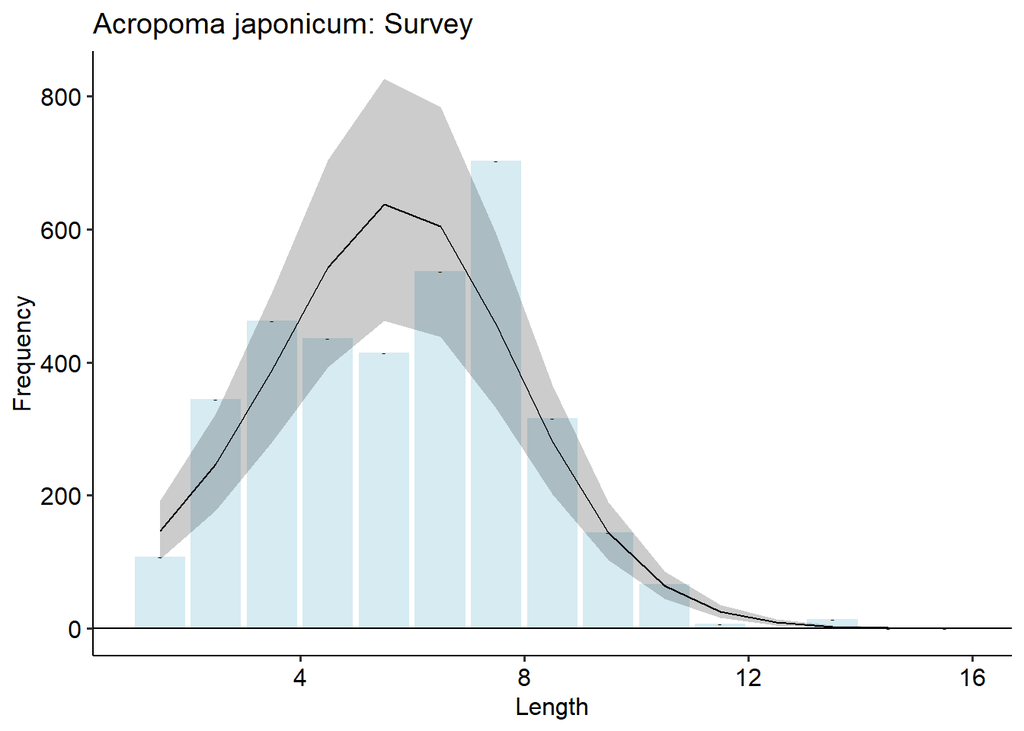

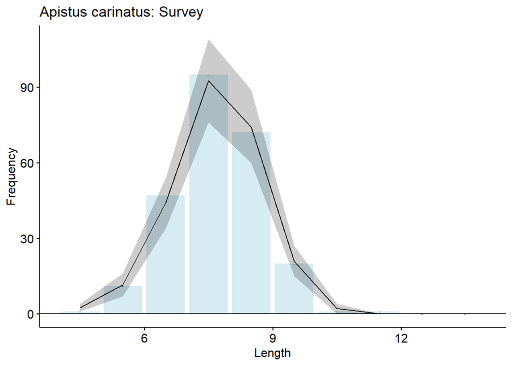

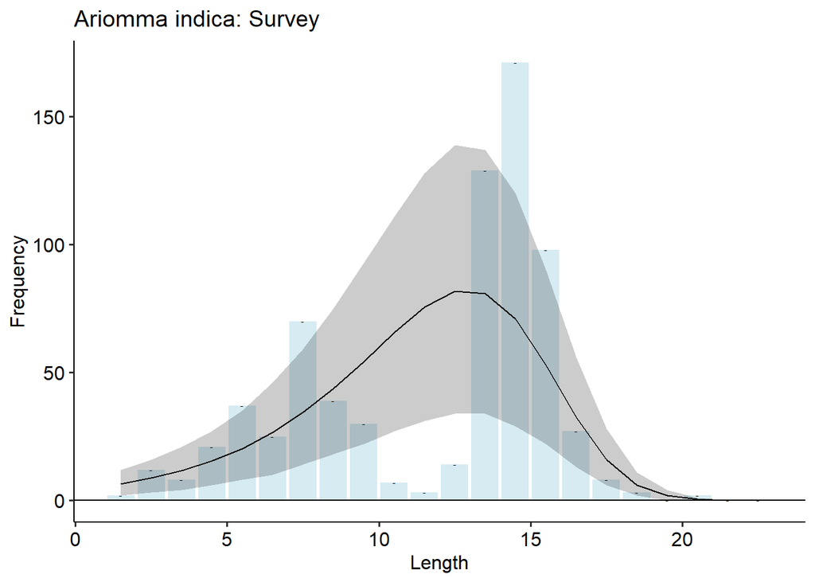

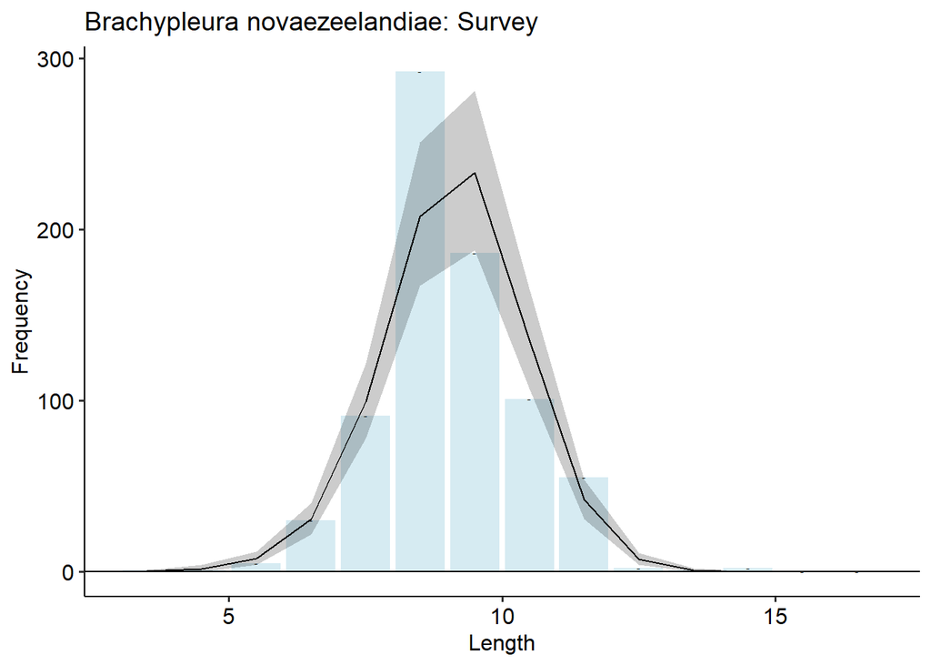

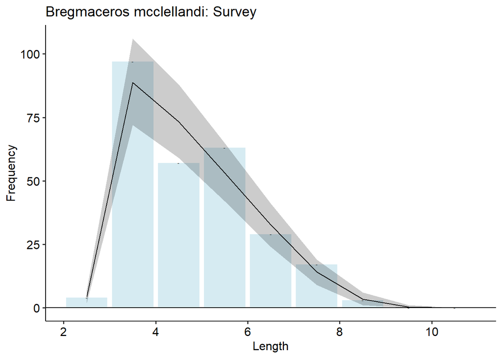

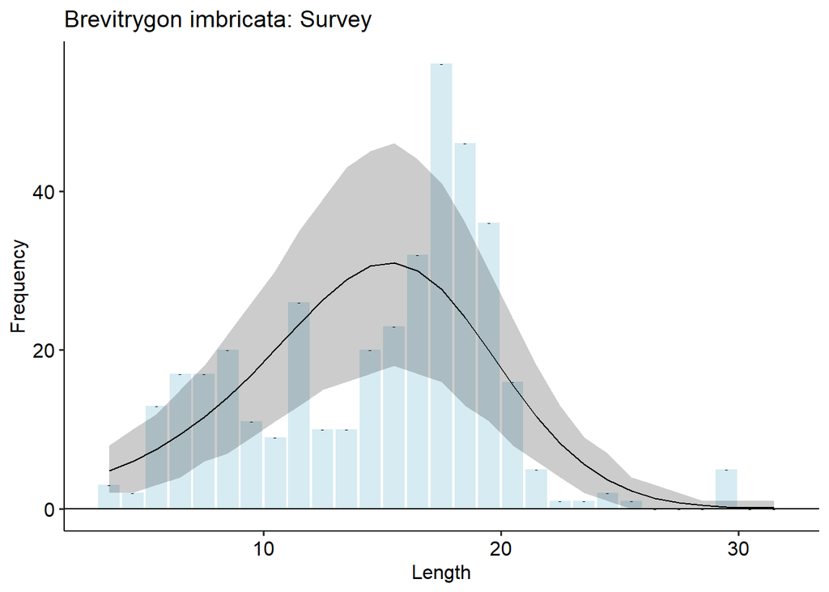

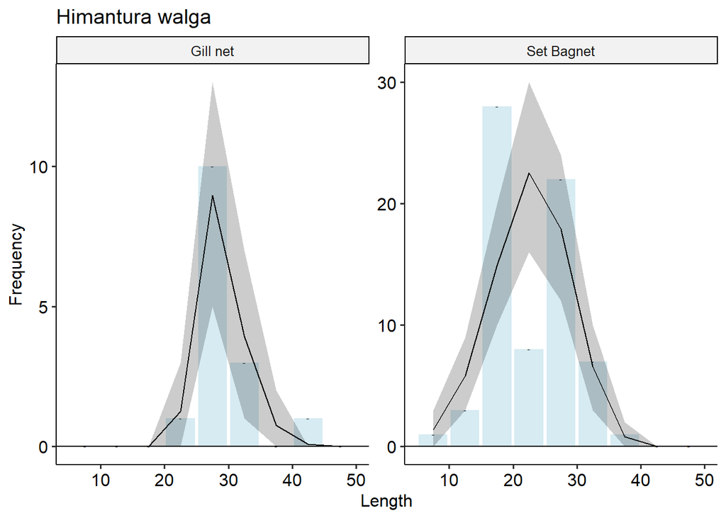

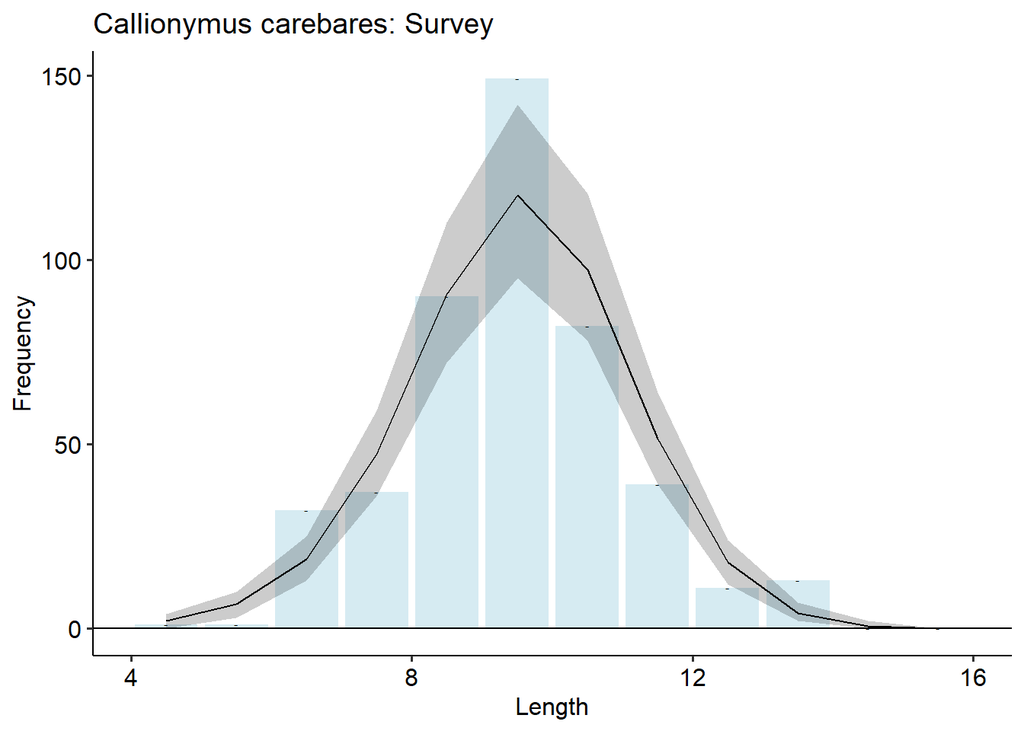

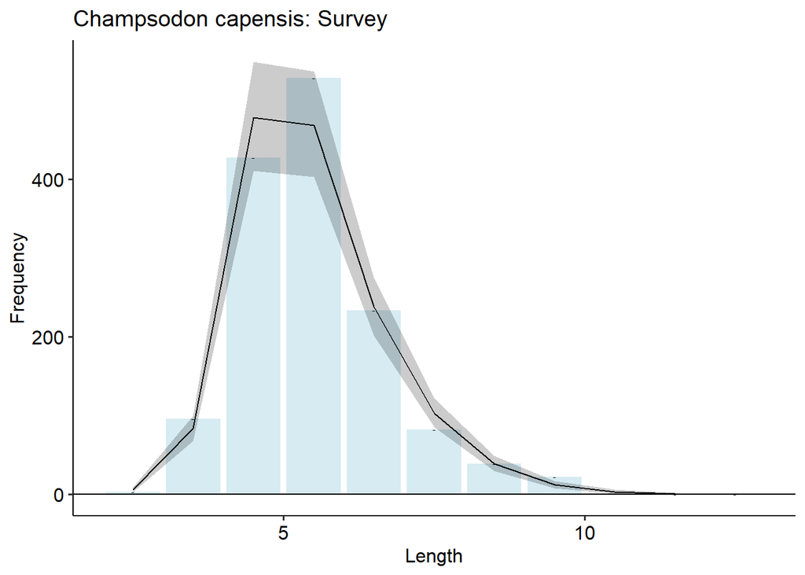

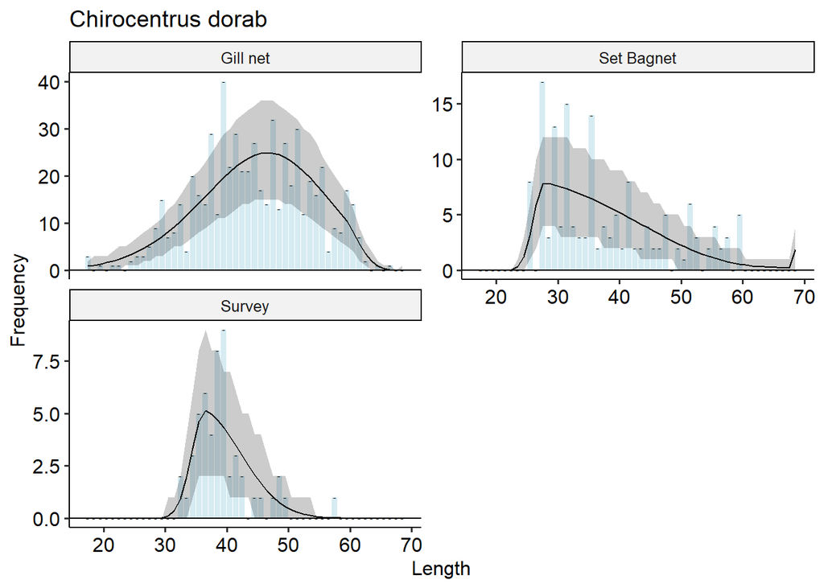

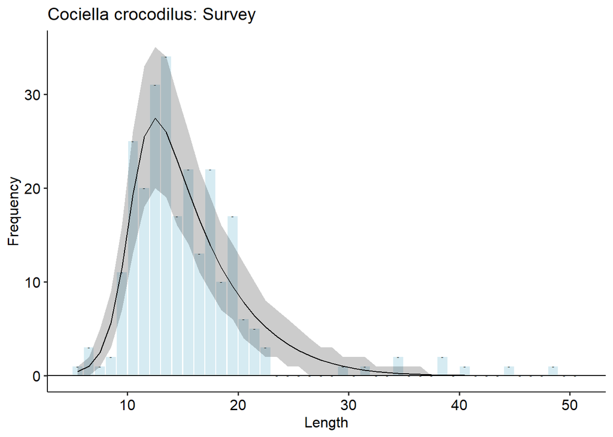

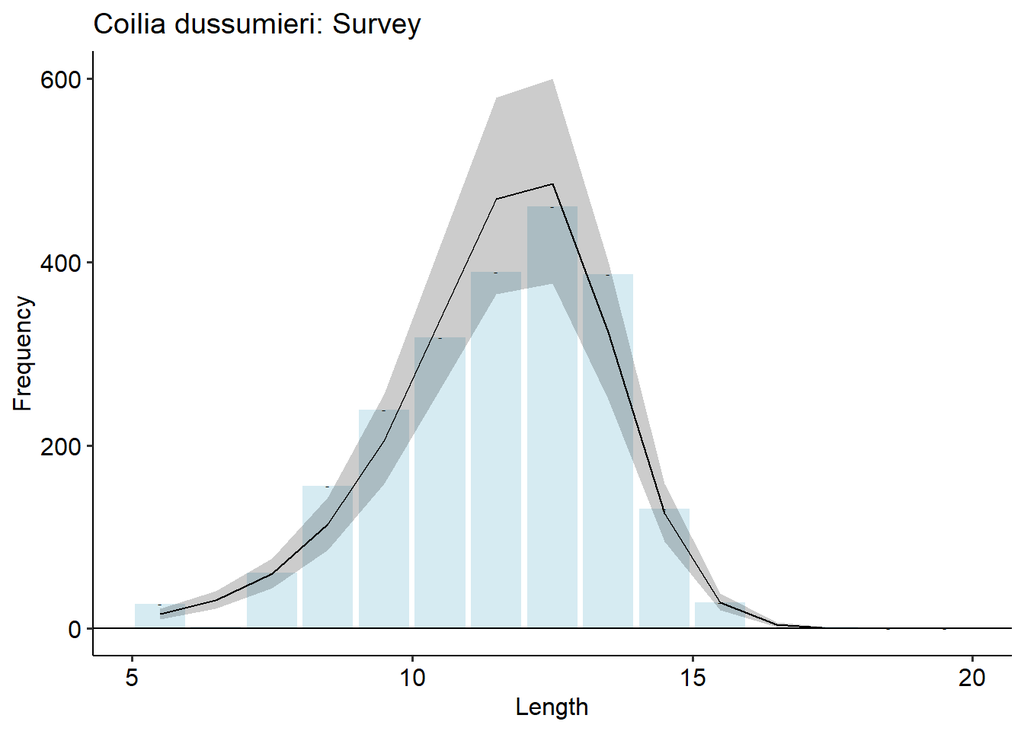

[100 more figures not shown]

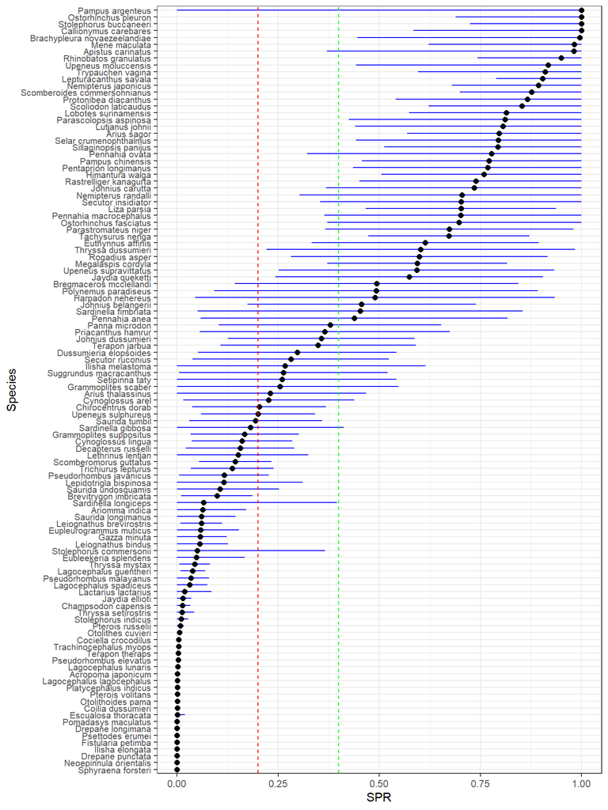

```r
SPR_df <- mpdall |>
  filter(par=="SPR", !is.na(mpd)) |>
  mutate(SPR_min = mpd-se*1.644853626951,
         SPR_max = mpd+se*1.644853626951,
         SPR_min = ifelse(SPR_min < 0 | is.na(SPR_min), 0, SPR_min),
         SPR_max = ifelse(SPR_max > 1 | is.na(SPR_max), 1, SPR_max)) |>
  arrange(mpd)

spp <- pull(SPR_df, Species)

SPR_df <- SPR_df |>
  mutate(Species = factor(Species, levels=spp))

ggplot(SPR_df, aes(y=Species)) +
  geom_linerange(aes(xmin=SPR_min, xmax=SPR_max), linetype=1, color="blue") +
  geom_point(aes(x=mpd), size=2, color="black") +
  labs(x="SPR") +
  geom_vline(xintercept=0.4, colour="green", linetype=2) +
  geom_vline(xintercept=0.2, colour="red", linetype=2) +
  theme_bw() +
  theme(axis.text.y=element_text(size=8))
```

# Conclusion

These results are preliminary and should not be used for assessing individual species at this point. This analysis will be replaced by a more rigorous analysis of each species. Nevertheless, the analysis provides a useful overview of the length frequency data and indicates that some species are at high risk of overfishing.

The graphs show that the model has a poor fit to some data and it is likely the model will need to be adapted. Some length data still exhibits bimodal frequency which will need to addressed. All gears and sources of data (survey, artisanal and industrial) need to be included into single catch curves to account for all sources of mortality and information on stock length structure. Most importantly length frequency from the industrial fishery is missing.

The results from this type of analysis when complete will only provide a risk assessment for each species. Single length samples will not provide definitive results on stock status. The overall evidence, however, is that a significant proportion of the species may be overexploited. Out of the 112 species, 53 (47%) were estimated below the suggested limit reference point (SPR20%) and 66 (59%) below the suggested target reference point (SPR40%).

In the final analysis, it is likely different species may be given different status as scientific evaluation improves, but almost certainly a significant proportion will remain below the limit reference point and be considered at high risk of over harvesting. Given the large number of species present in Bangladesh fisheries, maintaining all in the target region will not be possible.

The only way to achieve a multispecies objective will most probably be through a series of controls on overall harvest rates, seasonal closed areas, and technical controls on fishing activities. It can also be expected that this will take many years to achieve through a management cycle of implementation of controls, evaluation of performance and adjustment.